# Weather Data Preparation and Wrangling

Lorenz Menendez

12/19/2019

This project uses weather and pollution data from remotely sensed satellite imagery, but also ground based sensors maintained by the EPA to model air quality in the Midwest. Using the ground sensors, the team can determine how accurate the models are at predicting air quality. This chapter focuses on how weather and pollution data from EPA gorund sensors was downloaded and prepared for use in refining air quality models.

## Querying EPA Data in R

EPA data was seamlessly imported into R using a custom package, named **epadata**. The package takes advanatge of the [EPA AQS DataMart API](https://aqs.epa.gov/aqsweb/documents/data_mart_welcome.html) to load data in R as data.frame objects with only a couple lines of code. It allows users to query for sensor data across multiple years, states, and air quality variables. Let’s get started by downloading the package, then we’ll do a walkthrough of the **epadata** package.

```r
devtools::install_url('https://uchicago.box.com/shared/static/jwpi7l89t58lm1sukit2tvcdavs5sz5t.zip', quiet = TRUE)

library(epadata)
```

### Getting Started

This section describes the process for querying EPA sensor data using the **epadata** package. For more information on how each function works, please reference the package documentation.

#### Registering for an API Key

For first time users of the AQS DataMart API, you must first register your email to recieve an API key as shown below.

```r
API.signup('YourEmailHere@uchicago.edu')
```

```
## Check your inbox at (YourEmailHere@uchicago.edu) for your API key
```

Save your API key from the email confirmation for future reference. In case you don’t recieve an email, verify that your email address was typed correctly, and check your spam folder.

#### Your First Data Query

Below, we’ll query for PM2.5 data across Indiana and Wisconsin for the years 2017 and 2018 using the *EPA.daily.summary()* function from the **epadata** package. This function will return a data.table containing a record of the daily average of the selected variable for all **available** days of the selected year in the selected state.

```r
PM25.data = EPA.daily.summary(email = email,
                                  key = key,
                                  year.range = 2017:2018,
                                  state.FIPS.list = list(18, 55),
                                  pollutant.code = 88502)
```

```
## Querying API for pollutant 88502 between 20170101 and 20171231 in state 18
```

```
## Querying API for pollutant 88502 between 20180101 and 20181231 in state 18
```

```
## Querying API for pollutant 88502 between 20170101 and 20171231 in state 55
```

```
## Querying API for pollutant 88502 between 20180101 and 20181231 in state 55
```

```r
head(PM25.data)
```

```
##   state_code county_code site_number parameter_code poc latitude longitude
## 1         55         041        0007          88502   1   45.565  -88.8086
## 2         55         041        0007          88502   1   45.565  -88.8086
## 3         55         041        0007          88502   1   45.565  -88.8086
## 4         55         041        0007          88502   1   45.565  -88.8086
## 5         55         041        0007          88502   1   45.565  -88.8086
## 6         55         041        0007          88502   1   45.565  -88.8086
##   datum                              parameter sample_duration
## 1 NAD83 Acceptable PM2.5 AQI & Speciation Mass         24 HOUR
## 2 NAD83 Acceptable PM2.5 AQI & Speciation Mass         24 HOUR
## 3 NAD83 Acceptable PM2.5 AQI & Speciation Mass         24 HOUR
## 4 NAD83 Acceptable PM2.5 AQI & Speciation Mass         24 HOUR
## 5 NAD83 Acceptable PM2.5 AQI & Speciation Mass         24 HOUR
## 6 NAD83 Acceptable PM2.5 AQI & Speciation Mass         24 HOUR
##   pollutant_standard date_local            units_of_measure event_type
```

[output cut: 41 more lines]

Notice how for each each data request, you must specify which **timeframe** (year.range) = 2017:2018), **states** (state.FIPS.list = list(18, 55)), and which **pollutant/weather variable** (pollutant.code = 88502) to query for. Inputting this data might not be strightforward at first, but the package has some other built-in functions to help you.

### Selecting timeframes, states, and pollutant/weather variables

- **Timeframes**: This is the simplest variable to select, as it is simply a number range representing the year. More granular timescales can be extracted from queried data if needed.

```r
year.range = 2014:2018 # Query for data in years 2014, 2015, 2016, 2017, and 2018
year.range = 2016:2016 # Query for data in 2016 only
```

- **States**: You must input the state(s) [FIPS](https://en.wikipedia.org/wiki/Federal_Information_Processing_Standard_state_code) code because the DataMart API uses this as a parimary key for all U.S. states.

```r
state.FIPS.list = list(18, 55) # Query for data in Indiana (18) and Wisconsin (55)
state.FIPS.list = list(17) # Query for data in Illinois (17) only.
```

If you don’t know the FIPS code associated with the State you’re querying for, the following function will return a data table containing the FIPS code for each State.

```r
FIPS.codes = state.list(email, key)

head(FIPS.codes)
```

```
##   code value_represented
## 1   01           Alabama
## 2   02            Alaska
## 3   04           Arizona
## 4   05          Arkansas
## 5   06        California
## 6   08          Colorado
```

- **Pollutant/Weather Variable**: The EPA has a large bank of variables to choose from. Variables are first categorized as classes. A listing of available classes can be quried from the API as shown below. Each class has a unique code assigned to it.

```r
class.codes = class.list(email, key)

head(class.codes)
```

```
##             code
## 1    AIRNOW MAPS
## 2            ALL
## 3 AQI POLLUTANTS
## 4      CORE_HAPS
## 5       CRITERIA
## 6       CSN DART
##                                                     value_represented
## 1 The parameters represented on AirNow maps (88101, 88502, and 44201)
## 2                                     Select all Parameters Available
## 3                                 Pollutants that have an AQI Defined
## 4                                          Urban Air Toxic Pollutants
## 5                                                 Criteria Pollutants
## 6     List of CSN speciation parameters to populate the STI DART tool
```

Using your chosen class code, you can find the individual variables within each class. Alternatrively, you can also query for all variables, but this is not recommended as the list is very large.

```r
variable.codes.1 = variable.list(email, key, class = 'CORE_HAPS') # Search for variables in the Urban Air Toxic Pollutants class.
```

```r
variable.codes.2 = variable.list(email, key, class = 'ALL') # Returns all available EPA vairables. NB: This will create a very large data.table.
```

#### Advanced Querying

- **Fetching Daily Summaries for Multiple Variables** in a single query is not recommended, due to long processing times and large datasets. However, you may choose to do this usign the **apply** family of functions, as shown below.

```r
pollutant.codes = list(88502, 81102) # Two pollutant codes

pollutant.data = lapply(pollutant.codes, FUN = function(x){
    EPA.daily.summary(email = email,
                      key = 'tealmouse67',
                      year.range = 2017:2018,
                      state.FIPS.list = list(18, 55),
                      pollutant.code = x)

}) %>%  do.call("rbind", .)

# Verifying that multiple pollutant variables were chosen
unique(pollutant.data$parameter)
```

### Sensor Locations and Metadata

The **epadata** package also allows you to query for station location and other metadata. The function below does this for you, and has a similar usage to the *daily.summary()* function.

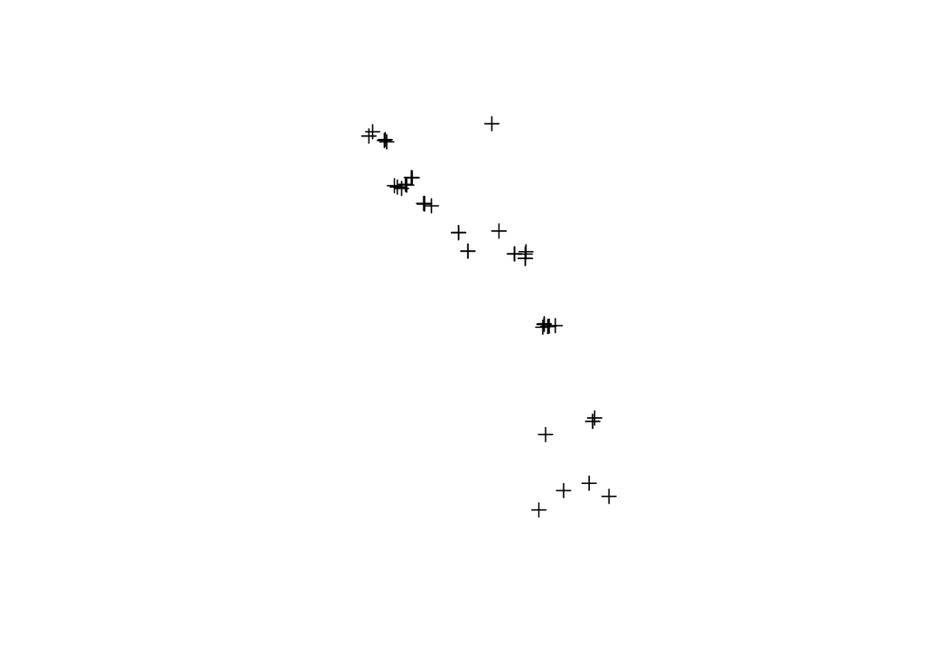

```r
sensors = EPA.monitor.locations(email = email,
                                    key = key,
                                    year.range = 2017:2018,
                                    state.FIPS.list = list(18, 55),
                                    pollutant.code = list(88502, 81102))

plot(sensors)
```

By default, the function will return a spatial object. However, you can forego the spatial data component and keep only the attribute table by changing spatial to FALSE as shown below.

```r
EPA.sensors.df = EPA.monitor.locations(email = email,
                                    key = key,
                                    year.range = 2017:2018,
                                    state.FIPS.list = list(18, 55),
                                    pollutant.code = list(88502, 81102),
                                    spatial = FALSE)

head(EPA.sensors.df)
```

```
##   state_code county_code site_number parameter_code poc
## 1         18         089        2004          88502   5
## 2         18         175        9000          88502   1
## 5         55         041        0007          88502   1
## 7         18         019        0006          81102   1
## 8         18         037        2001          81102   2
## 9         18         097        0078          81102   4
##                           parameter_name  open_date close_date
## 1 Acceptable PM2.5 AQI & Speciation Mass 2004-01-04       <NA>
## 2 Acceptable PM2.5 AQI & Speciation Mass 2001-03-08       <NA>
## 5 Acceptable PM2.5 AQI & Speciation Mass 2016-11-17       <NA>
## 7                  PM10 Total 0-10um STP 2003-06-26       <NA>
## 8                  PM10 Total 0-10um STP 1987-07-06       <NA>
## 9                  PM10 Total 0-10um STP 2012-05-21       <NA>
##   concurred_exclusions dominant_source measurement_scale
```

[output cut: 104 more lines]